# Chapter 2 Notes

## 2.1 tsibble objects

Formerly a `ts()` object, `tsibble()` is the new way to establish a timeseries object

```
y <- tsibble(
  Year = 2015:2019,
  Observation = c(123, 39, 78, 52, 110),
  index = Year
)
```

`tsibble` objects extend tidy data frames (``tibble` objects) by introducing temporal structure.

When observations are more frequent that yearly, a timeclass function must be used as the index. Below is a monthly `tibble` df:

```
#> # A tibble: 5 x 2
#>   Month    Observation
#>   <chr>          <dbl>
#> 1 2019 Jan          50
#> 2 2019 Feb          23
#> 3 2019 Mar          34
#> 4 2019 Apr          30
#> 5 2019 May          25
```

In order to convert to `tsibble`, convert the `Month` column from `<chr>` to `<mth>` using `yearmonth()` and identifying `index` variable with `as_tsibble()`:

```
z %>%
  mutate(Month = yearmonth(Month)) %>%
  as_tsibble(index = Month)
```

**Other Time Class Functions**

| Feature | Function |
| --- | --- |
| Annual | `start:end` |
| Quarterly | `yearquarter()` |
| Monthly | `yearmonth()` |
| Weekly | `yearweek()` |
| Daily | `as_date()`, `ymd()` |
| Sub-daily | `as_datetime()`, `ymd_hms()` |

**Working with `tsibble` Objects**

We can use `dplyr` functions on `tsibble` objects.Examples below using the PBS tsibble containing sales data on pharmaceutical products in Australia

```r
PBS
```

```
## # A tsibble: 67,596 x 9 [1M]
## # Key:       Concession, Type, ATC1, ATC2 [336]
##       Month Concession  Type   ATC1  ATC1_desc   ATC2  ATC2_desc   Scripts  Cost
##       <mth> <chr>       <chr>  <chr> <chr>       <chr> <chr>         <dbl> <dbl>
##  1 1991 Jul Concession~ Co-pa~ A     Alimentary~ A01   STOMATOLOG~   18228 67877
##  2 1991 Aug Concession~ Co-pa~ A     Alimentary~ A01   STOMATOLOG~   15327 57011
##  3 1991 Sep Concession~ Co-pa~ A     Alimentary~ A01   STOMATOLOG~   14775 55020
##  4 1991 Oct Concession~ Co-pa~ A     Alimentary~ A01   STOMATOLOG~   15380 57222
##  5 1991 Nov Concession~ Co-pa~ A     Alimentary~ A01   STOMATOLOG~   14371 52120
##  6 1991 Dec Concession~ Co-pa~ A     Alimentary~ A01   STOMATOLOG~   15028 54299
##  7 1992 Jan Concession~ Co-pa~ A     Alimentary~ A01   STOMATOLOG~   11040 39753
##  8 1992 Feb Concession~ Co-pa~ A     Alimentary~ A01   STOMATOLOG~   15165 54405
##  9 1992 Mar Concession~ Co-pa~ A     Alimentary~ A01   STOMATOLOG~   16898 61108
## 10 1992 Apr Concession~ Co-pa~ A     Alimentary~ A01   STOMATOLOG~   18141 65356
## # ... with 67,586 more rows
```

Using the `filter()` function to call specific value from column:

```r
PBS %>%
  filter(ATC2 == 'A10')
```

```
## # A tsibble: 816 x 9 [1M]
## # Key:       Concession, Type, ATC1, ATC2 [4]
##       Month Concession  Type   ATC1  ATC1_desc   ATC2  ATC2_desc  Scripts   Cost
##       <mth> <chr>       <chr>  <chr> <chr>       <chr> <chr>        <dbl>  <dbl>
##  1 1991 Jul Concession~ Co-pa~ A     Alimentary~ A10   ANTIDIABE~   89733 2.09e6
##  2 1991 Aug Concession~ Co-pa~ A     Alimentary~ A10   ANTIDIABE~   77101 1.80e6
##  3 1991 Sep Concession~ Co-pa~ A     Alimentary~ A10   ANTIDIABE~   76255 1.78e6
##  4 1991 Oct Concession~ Co-pa~ A     Alimentary~ A10   ANTIDIABE~   78681 1.85e6
##  5 1991 Nov Concession~ Co-pa~ A     Alimentary~ A10   ANTIDIABE~   70554 1.69e6
##  6 1991 Dec Concession~ Co-pa~ A     Alimentary~ A10   ANTIDIABE~   75814 1.84e6
##  7 1992 Jan Concession~ Co-pa~ A     Alimentary~ A10   ANTIDIABE~   64186 1.56e6
##  8 1992 Feb Concession~ Co-pa~ A     Alimentary~ A10   ANTIDIABE~   75899 1.73e6
##  9 1992 Mar Concession~ Co-pa~ A     Alimentary~ A10   ANTIDIABE~   89445 2.05e6
## 10 1992 Apr Concession~ Co-pa~ A     Alimentary~ A10   ANTIDIABE~   97315 2.23e6
## # ... with 806 more rows
```

Selecting the specific columns we need with `select()`:

```r
PBS %>%
  filter(ATC2 == 'A10') %>%
  select(Month, Concession, Type, Cost)
```

```
## # A tsibble: 816 x 4 [1M]
## # Key:       Concession, Type [4]
##       Month Concession   Type           Cost
##       <mth> <chr>        <chr>         <dbl>
##  1 1991 Jul Concessional Co-payments 2092878
##  2 1991 Aug Concessional Co-payments 1795733
##  3 1991 Sep Concessional Co-payments 1777231
##  4 1991 Oct Concessional Co-payments 1848507
##  5 1991 Nov Concessional Co-payments 1686458
##  6 1991 Dec Concessional Co-payments 1843079
##  7 1992 Jan Concessional Co-payments 1564702
##  8 1992 Feb Concessional Co-payments 1732508
##  9 1992 Mar Concessional Co-payments 2046102
## 10 1992 Apr Concessional Co-payments 2225977
## # ... with 806 more rows
```

`select()` handles columns while `filter()` handles rows

`summarize()` allows you to combine data across keys:

```r
PBS %>%
  filter(ATC2 == 'A10') %>%
  select(Month, Concession, Type, Cost) %>%
  summarize(TotalC = sum(Cost))
```

```
## # A tsibble: 204 x 2 [1M]
##       Month  TotalC
##       <mth>   <dbl>
##  1 1991 Jul 3526591
##  2 1991 Aug 3180891
##  3 1991 Sep 3252221
##  4 1991 Oct 3611003
##  5 1991 Nov 3565869
##  6 1991 Dec 4306371
##  7 1992 Jan 5088335
##  8 1992 Feb 2814520
##  9 1992 Mar 2985811
## 10 1992 Apr 3204780
## # ... with 194 more rows
```

Creating new variables using `mutate()`

```r
PBS %>%
  filter(ATC2 == 'A10') %>%
  select(Month, Concession, Type, Cost) %>%
  summarize(TotalC = sum(Cost)) %>%
  mutate(Cost = TotalC/1e6)
```

```
## # A tsibble: 204 x 3 [1M]
##       Month  TotalC  Cost
##       <mth>   <dbl> <dbl>
##  1 1991 Jul 3526591  3.53
##  2 1991 Aug 3180891  3.18
##  3 1991 Sep 3252221  3.25
##  4 1991 Oct 3611003  3.61
##  5 1991 Nov 3565869  3.57
##  6 1991 Dec 4306371  4.31
##  7 1992 Jan 5088335  5.09
##  8 1992 Feb 2814520  2.81
##  9 1992 Mar 2985811  2.99
## 10 1992 Apr 3204780  3.20
## # ... with 194 more rows
```

Saving as a tsibble():

```r
a10 <- PBS %>%
  filter(ATC2 == 'A10') %>%
  select(Month, Concession, Type, Cost) %>%
  summarize(TotalC = sum(Cost)) %>%
  mutate(Cost = TotalC/1e6)
```

**Reading CSVs**

```r
prison <- readr::read_csv("https://OTexts.com/fpp3/extrafiles/prison_population.csv")
# The original CSV has the date variable as individual days and they should be quarters

prison <- prison %>%
  mutate(Quarter = yearquarter(Date)) %>%
  select(-Date) %>%
  as_tsibble(key = c(State, Gender, Legal, Indigenous),
             index = Quarter)

prison
```

```
## # A tsibble: 3,072 x 6 [1Q]
## # Key:       State, Gender, Legal, Indigenous [64]
##    State Gender Legal    Indigenous Count Quarter
##    <chr> <chr>  <chr>    <chr>      <dbl>   <qtr>
##  1 ACT   Female Remanded ATSI           0 2005 Q1
##  2 ACT   Female Remanded ATSI           1 2005 Q2
##  3 ACT   Female Remanded ATSI           0 2005 Q3
##  4 ACT   Female Remanded ATSI           0 2005 Q4
##  5 ACT   Female Remanded ATSI           1 2006 Q1
##  6 ACT   Female Remanded ATSI           1 2006 Q2
##  7 ACT   Female Remanded ATSI           1 2006 Q3
##  8 ACT   Female Remanded ATSI           0 2006 Q4
##  9 ACT   Female Remanded ATSI           0 2007 Q1
## 10 ACT   Female Remanded ATSI           1 2007 Q2
## # ... with 3,062 more rows
```

## 2.2 Time Plots

**Example of a time plot**

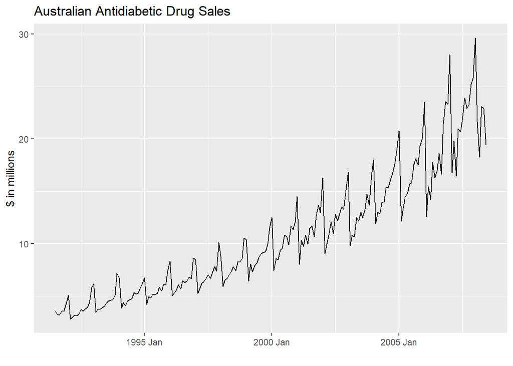

```r
autoplot(a10, Cost) +
  labs(y='$ in millions',
       x='',
      title= 'Australian Antidiabetic Drug Sales')
```

Plot shows:

- clear and increasing trend
- strong seasonal pattern
- increase in variance

Reason behind the shape:

- Government subsidizes in such a way that makes it cost-effective for patients to stockpile at the end of the calendar year, which leads to the drop at the beginning of each year.

## 2.3 Time Series Patterns

**Trend**: A long-term increase or decrease in the data.

**Seasonality**: When a pattern occurs in a fixed and known period of time, typically a year or less (i.e. hourly, weekly, monthly, quarterly).

**Cycle**: Occurs when the data exhibits a pattern not of fixed frequency usually on a scale > 2 years (i.e. market downturns every 7-10 years )

## 2.4 Seasonal Plots

A seasonal plot shows the data plotted against each individual “season”

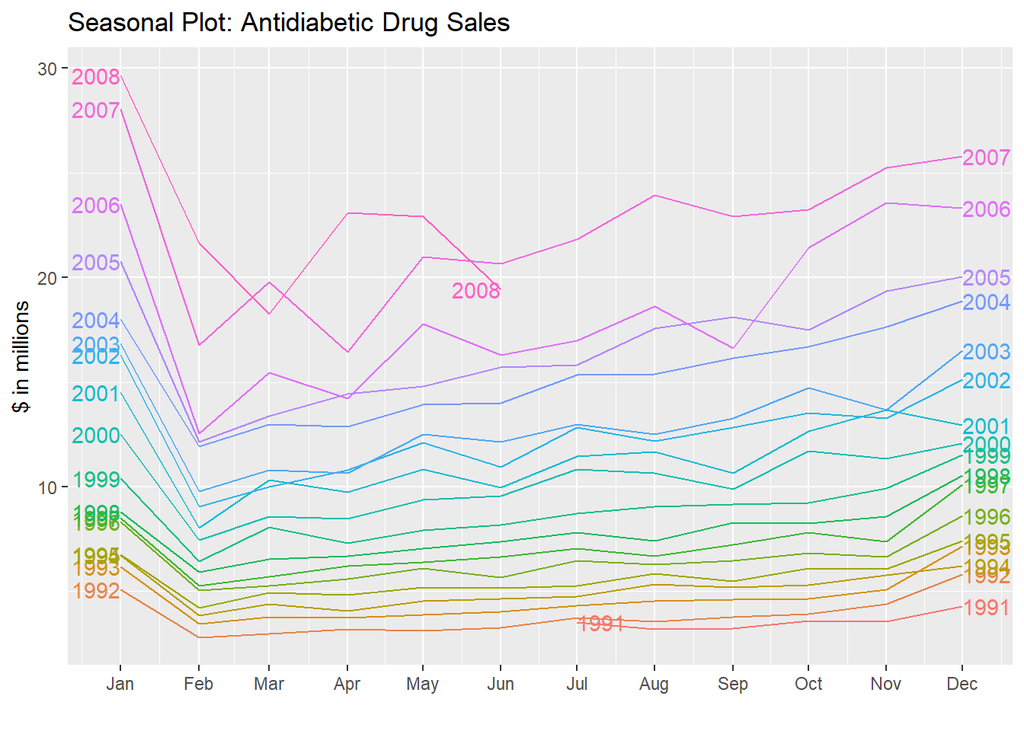

```r
a10 %>%
  gg_season(Cost, labels='both') +
  labs(y = '$ in millions',
       x='',
       title = 'Seasonal Plot: Antidiabetic Drug Sales') +
  expand_limits(x = ymd(c('1972-12-28','1973-12-04')))
```

**Multiple Seasonal Periods** In a case where data has more than one season pattern, use `period` argument.

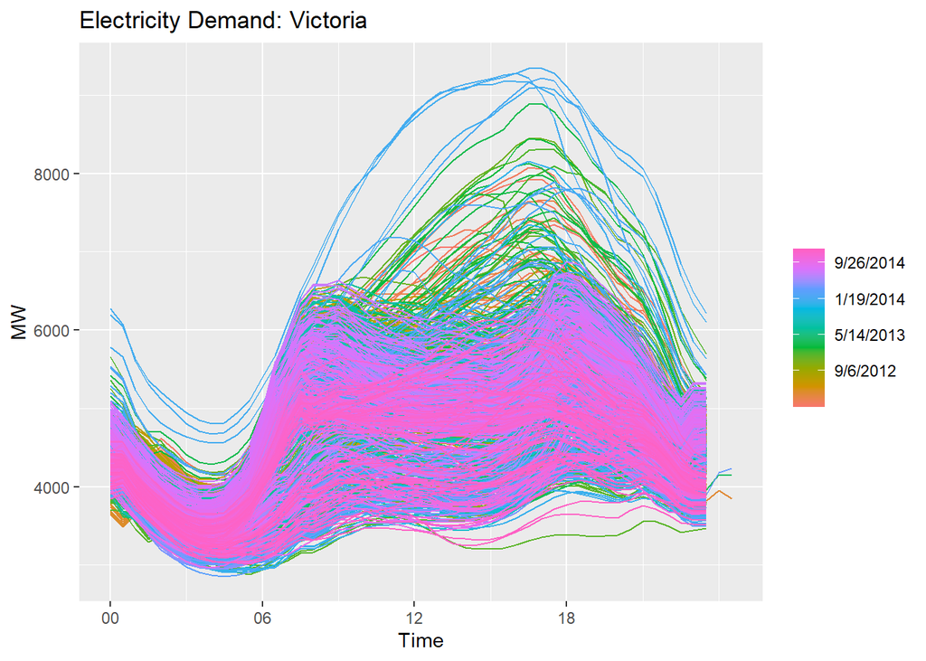

```r
vic_elec %>% gg_season(Demand, period='day') +
  #theme(legend.position = 'none') + #very unclear without the legend
  labs(y='MW', title='Electricity Demand: Victoria')
```

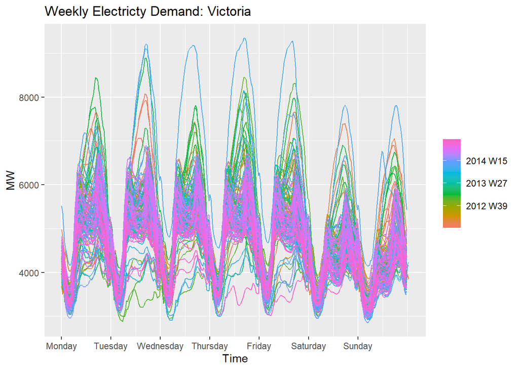

```r
vic_elec %>% gg_season(Demand, period='week') +
  labs(y='MW',title='Weekly Electricty Demand: Victoria')
```

## 2.5 Seasonal Subseries Plot

Alternative plot where data from each season is collected in a mini time plot

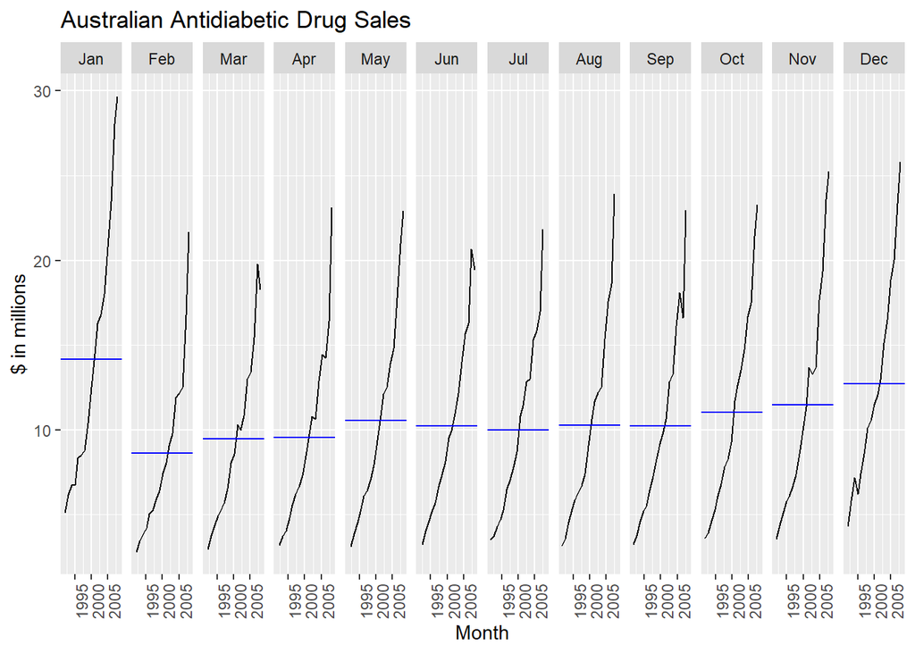

```r
a10 %>%
  gg_subseries(Cost)+
  labs(y = '$ in millions',
       title = 'Australian Antidiabetic Drug Sales'
  )
```

*What the plot shows*:

- Blue horizontal lines indicate means for each month.
- Seasonal pattern can be seen clearly
- Shows seasonal changes over time

#### Example: Australian Holiday Tourism

Using Australian quarterly vacation data to example seasonal subseries plots

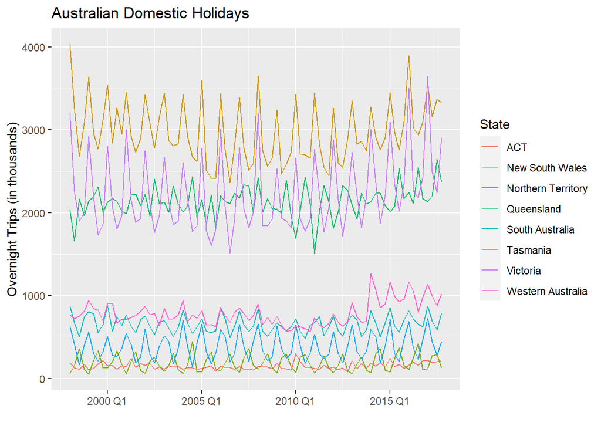

```r
holidays <- tourism %>%
  filter(Purpose == 'Holiday') %>% #total visitor nights on holiday
  group_by(State) %>% # grouped by state
  summarize(Trips = sum(Trips)) # total nights summed by state


autoplot(holidays, Trips) +
  labs(y='Overnight Trips (in thousands)',
       x='',
       title='Australian Domestic Holidays')
```

Above chart shows strong seasonality for most states. Seasonal peaks do not coincide.

To see seasonal peaks by time period, use season plot.

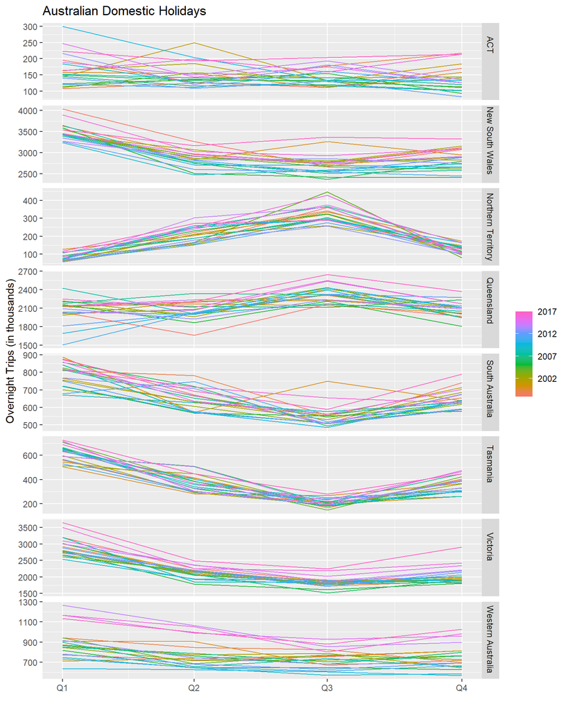

```r
gg_season(holidays, Trips) +
  labs(y='Overnight Trips (in thousands)',
       x='',
       title='Australian Domestic Holidays')
```

From the above graph we can see: * Southern states have strongest tourism in Q1 * Northern states have strongest tourism in Q3

The subseries plot is kind of a combination of the previous two graphs:

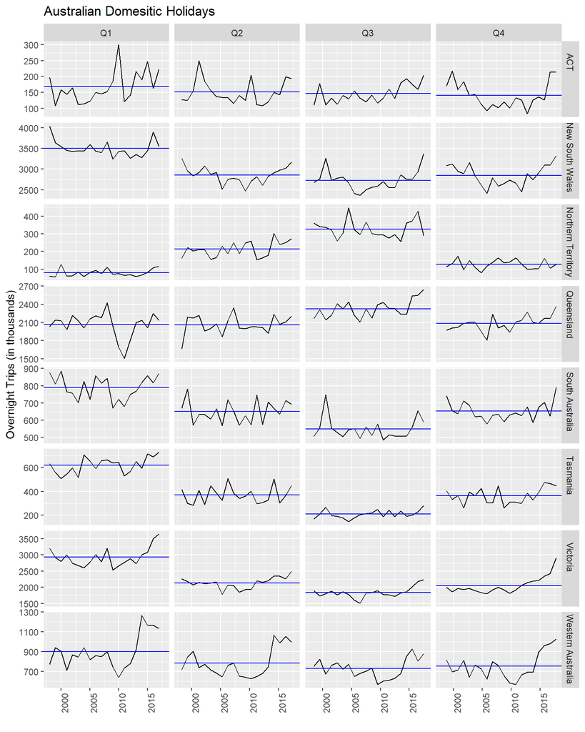

```r
holidays %>%
  gg_subseries(Trips) +
  labs(y='Overnight Trips (in thousands)',
       x='',
       title='Australian Domesitic Holidays')
```

From the above graph we can see: * All tourisim in Western Australia has increased over the years * Tourism has increased in Victoria recently only in Q1 and Q4

## 2.6 Scatter Plots

Used for exploring relationships between different time series. Here we look at half-hourly electric demand and temperature for Victoria, Australia.

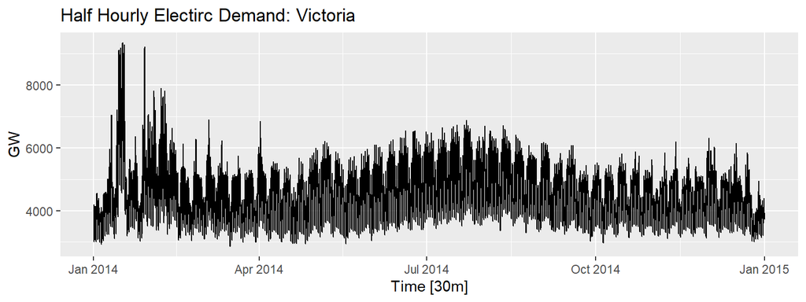

```r
vic_elec %>%
  filter(year(Time) == 2014) %>%
  autoplot(Demand) +
  labs(y='GW',
       title = 'Half Hourly Electirc Demand: Victoria')
```

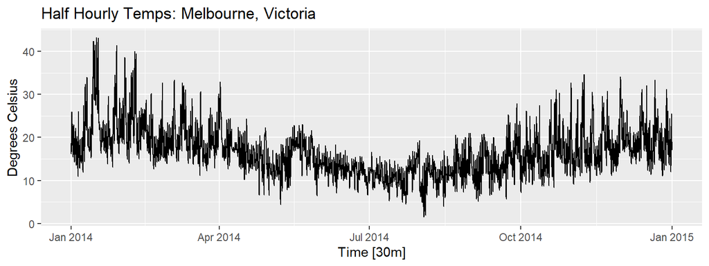

```r
vic_elec %>%
  filter(year(Time) == 2014) %>%
  autoplot(Temperature) +
  labs(
    y='Degrees Celsius',
    title = 'Half Hourly Temps: Melbourne, Victoria'
  )
```

Let’s plot these series against eachother:

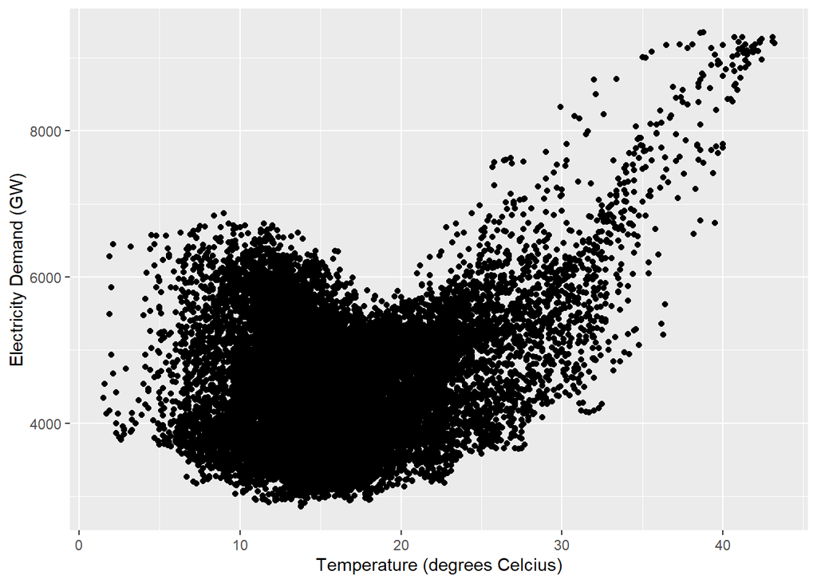

```r
vic_elec %>%
  filter(year(Time) == 2014) %>%
  ggplot(aes(x = Temperature, y = Demand)) +
  geom_point() +
  labs(x = 'Temperature (degrees Celcius)',
       y = 'Electricity Demand (GW)')
```

Clearly, high demand happens when temps are high and when temps are very low.

#### Correlation and Scatter Plot Matrices

If unclear what statistical correlation is, Google Pearson Correlation coefficient. In situations with several potential predictor variables, a scatter plot matrix compares all variables.

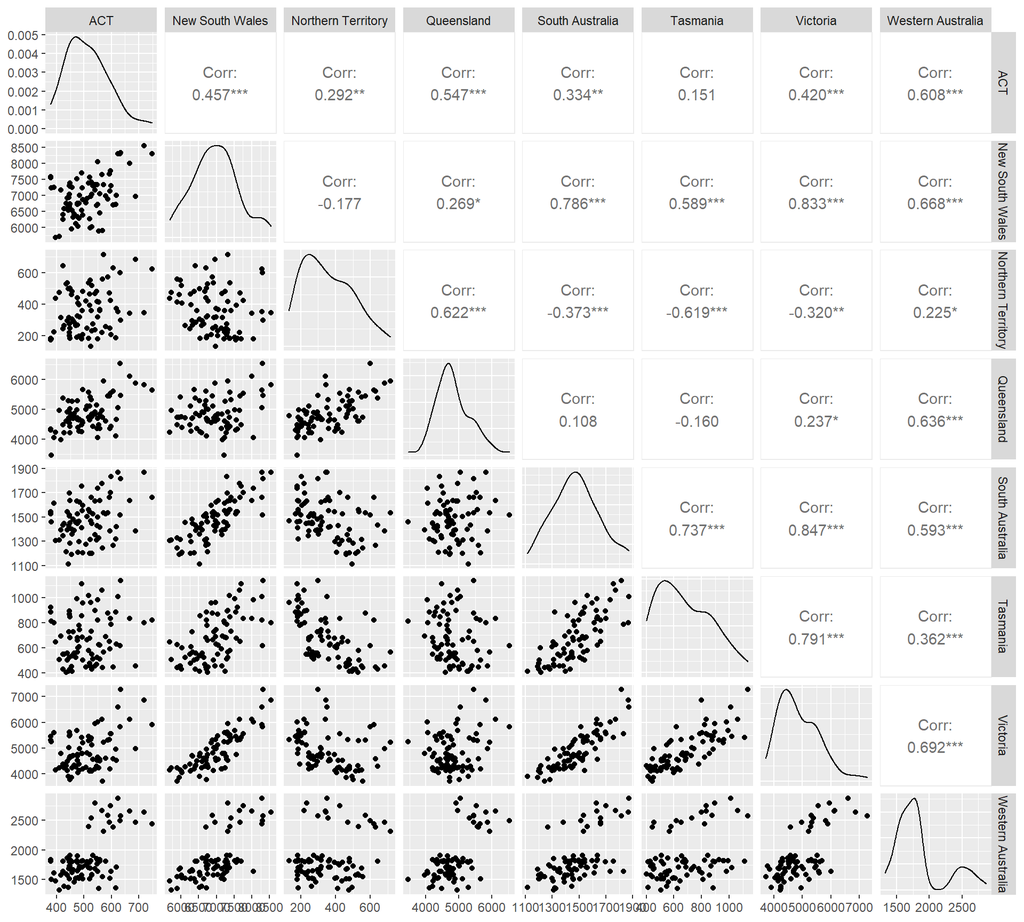

```r
visitors <- tourism %>%
  group_by(State) %>%
  summarise(Trips = sum(Trips))

visitors %>%
  pivot_wider(values_from = Trips, names_from = State) %>%
  ggpairs(columns = 2:9, progress = FALSE)
```

In the above, mostly positive relationships are revealed between the comparisons. Strongest relationships are between New South Wales, Victoria and South Australia, which are all southern. Negative relationships between Northern Territory and other regions as peak visitation times are seasonally opposite.

## 2.7 Lag Plots

Plot showing lagged values of the time series. Each graph shows $y_t$ plotted against $y_{t-k}$ for different values of $k$.

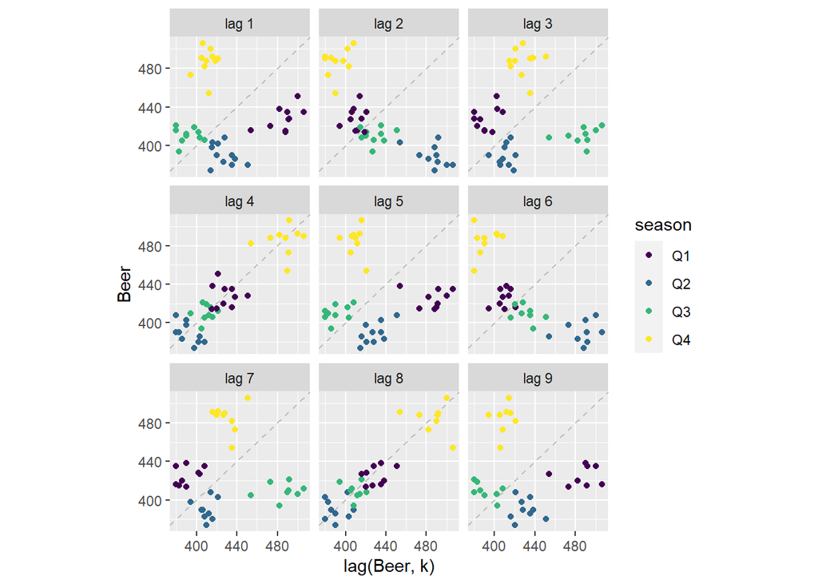

```r
recent_production <- aus_production %>%
  filter(year(Quarter) >= 2000)

recent_production %>%
  gg_lag(Beer, geom = 'point') +
  labs(x = 'lag(Beer, k)')
```

In this chart we see strong positive correlation at 4 & 8 lags reflecting strong seasonality. Negative relationship in 2 & 6 occurs because peaks in Q4 are plotted against troughs in Q2.

## 2.8 Autocorrelation

While correlation measures the linear relationship between two variables, autocorrelation measure the linear relationship between **lagged values** of a time series.

Autocorrelation can be computed using the `ACF()` function and then plotted using `autoplot()`

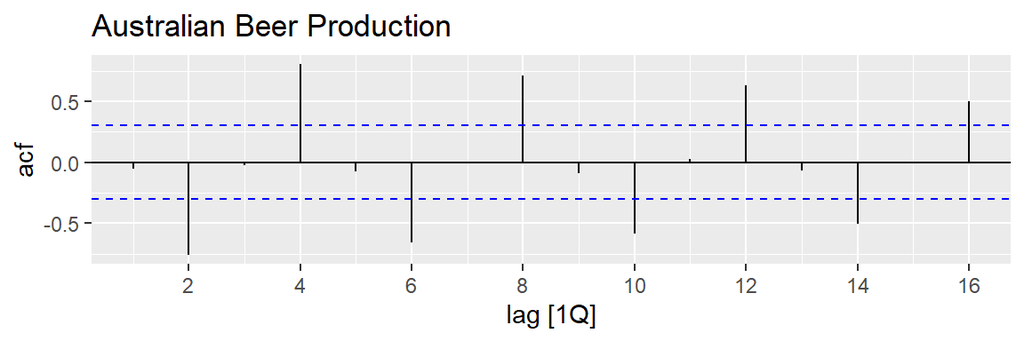

```r
recent_production %>%
  ACF(Beer) %>%
  autoplot() +
  labs(title = 'Australian Beer Production')
```

*Trend and Seasonality in ACF Plots*

ACF of seasonal data willl have autocorrelations at multiples of the seasonal period.

When data is trended and seasonal, there will be a combination.

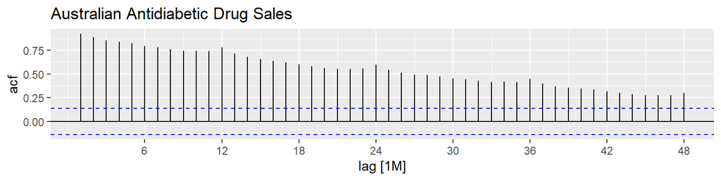

```r
a10 %>%
  ACF(Cost, lag_max = 48) %>%
  autoplot() +
  labs(title='Australian Antidiabetic Drug Sales')
```

## 2.9 White Noise

*White Noise* - a time series that shows no autocorrelation

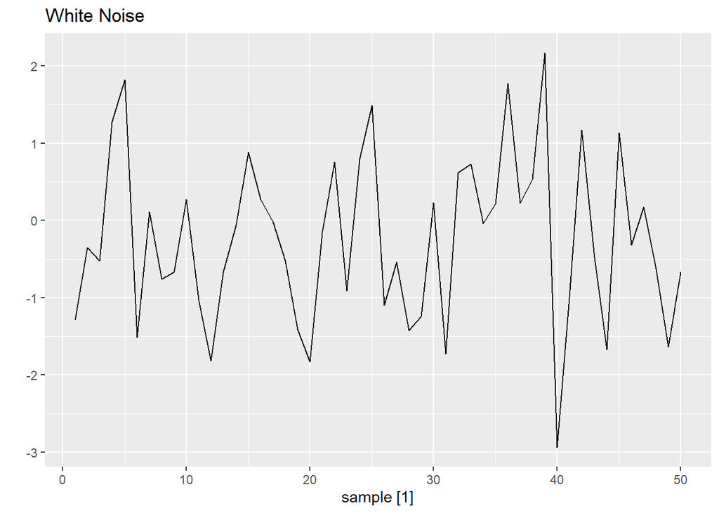

```r
set.seed(30)
y <- tsibble(sample = 1:50, wn = rnorm(50), index = sample)
y %>% autoplot(wn) + labs(title = "White Noise", y='')
```

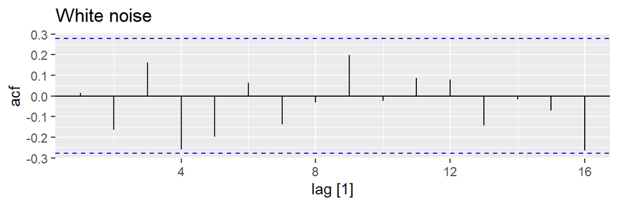

```r
y %>%
  ACF(wn) %>%
  autoplot() + labs(title = "White noise")
```

- We would expect 95% of ACF spikes to be inside of the blue lines
- If one or more large spikes or substantially more than 5% of spikes above blue bounds, then series is likely not white noise